# Spain at a Crossroads

## Part 4Can Sánchez hold on?

## Path 1: polling error

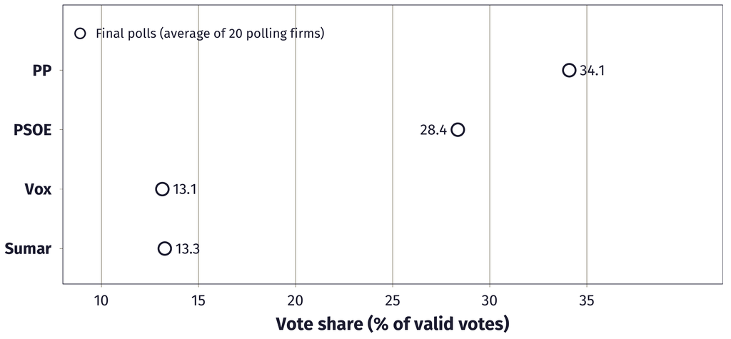

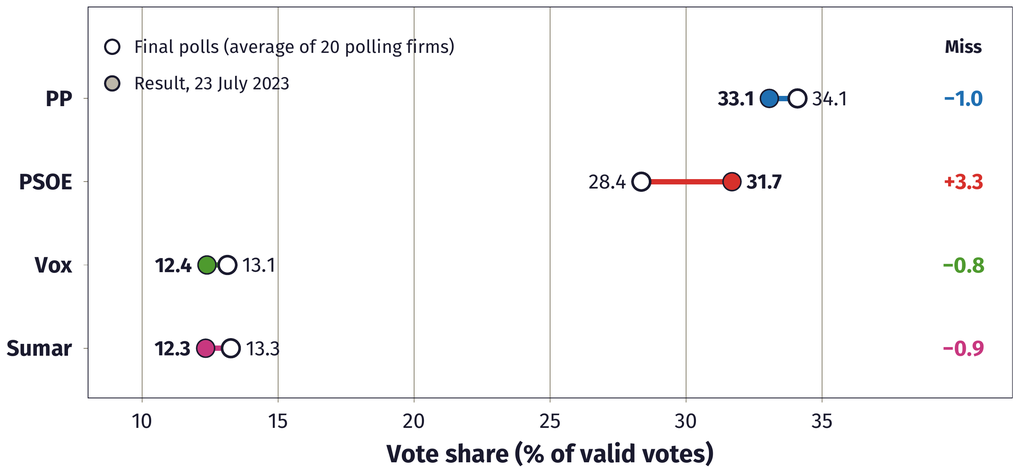

## Late deciders

[figure not shown]

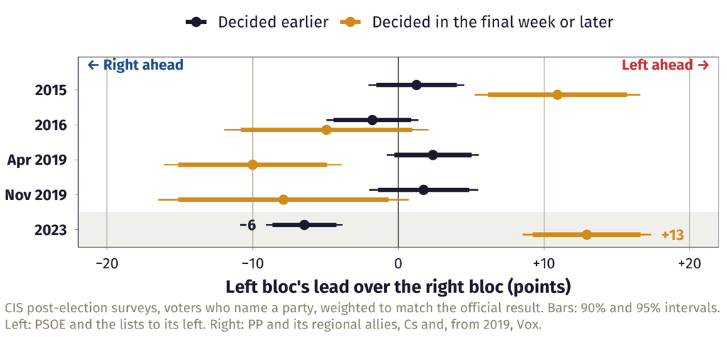

## Path 1: a 2023-sized polling error

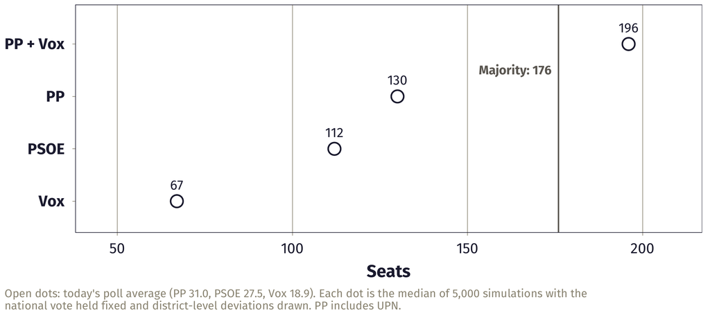

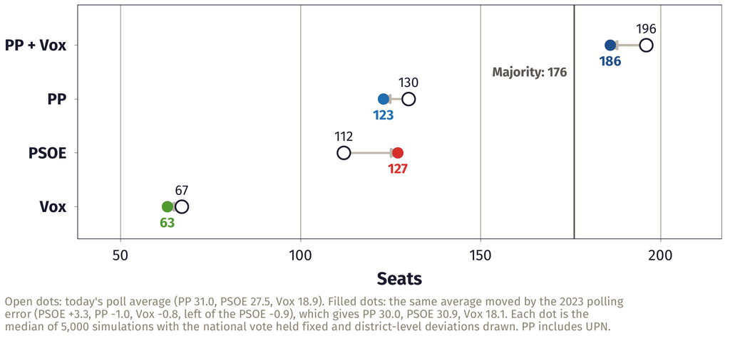

## Path 2: the leak to the PP

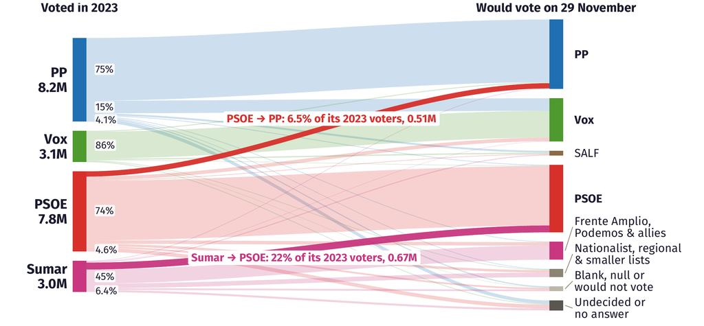

40dB pre-election survey for El País and Cadena SER, 2-4 Nov 2026 (n = 2,000), weighted to the 2023 result. The CIS pre-election survey (n = 45,074) shows the same direction: for every PP voter moving to the PSOE, about 4.5 PSOE voters move to the PP.

## Path 3: mobilisation

0.5MPSOE voters of 2023 who are now undecided, voting blank or staying home.

72.5%turnout for a PSOE-PP tie, if every extra voter picks the PSOE (2023: 70.4%). Sánchez asks for **“75 and 176”**.

Would it be enough? Half a million returning PSOE voters cut PP and Vox only to **191** seats; they still reach 176 in **91 of 100** simulations.

My estimates from 40dB’s pre-election microdata (2-4 Nov, n = 2,000), weighted to the 2023 result, and my seat model. “75 and 176”: Sánchez at Arnedo, 13 Nov.

## Path 4: tactical voting

[figure not shown]

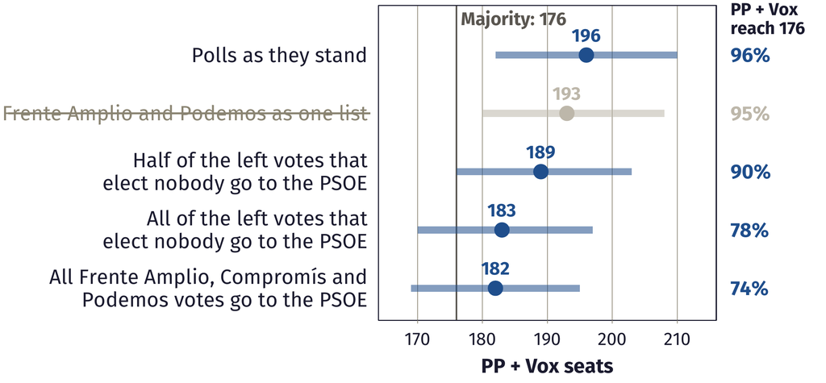

My seat model (polling errors since 1993), 10,000 simulated elections. Dots: middle result; bars: 8 in 10 simulations. Votes for Frente Amplio, Compromís or Podemos in a district where that list wins no seat move to the PSOE; nobody else changes their vote.

## All paths together

[figure not shown]

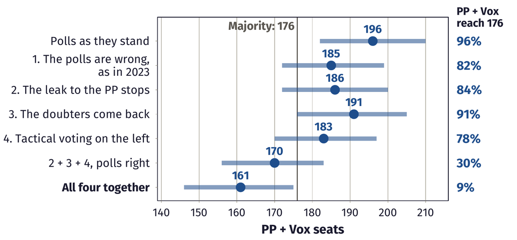

My seat model, 10,000 simulated elections for each row. Dots: middle result; bars: 8 in 10 simulations. “All four together” counts some voters twice (part of the 2023 miss was late deciders coming home): it is the best case for Sánchez.

## Part 5What is at stake?

## Calendar

[figure not shown]

[figure not shown]

On election night, three numbers: do PP and Vox reach 176 together (2023: 170)? Who comes first, PP or PSOE? How big is Vox? Dates after 29 Nov: Constitution art. 99, LOREG; the investiture and repeat-election windows follow the 2016-2023 precedents.

## If the left wins

Junts holds the key Junts rules out Feijóo, but also asks the PSOE for a candidate other than Sánchez. It wants a Catalan economic deal, immigration powers and protection for Catalan.

Many partners, few shared goals ERC, EH Bildu, PNV, BNG, Podemos and Frente Amplio: from the Basque centre-right to the radical left. Podemos and Frente Amplio both want seats in government.

The same arithmetic as 2023-26 After Junts broke with Sánchez in October 2025, the government lost its budget and its housing decrees. Blockage, and a repeat election, would stay on the table.

## If PP and Vox win

[figure not shown]

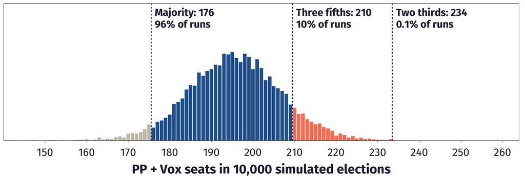

176: govern alone Invest Feijóo; rewrite organic laws on the amnesty, education, abortion, gender violence.

210: three fifths With the Senate: appoint Constitutional Court judges and the judicial council; amend most of the Constitution.

234: two thirds The Constitution’s core (unity, rights, the Crown), with a new election and a referendum.

## PP and Vox programmes

Where they mostly agree

- **Memory:** scrap the democratic memory law
- **Housing:** repeal the 2023 housing law
- **Schools:** replace the education law; teaching in Spanish everywhere
- **Courts and TV:** judges elect the judges’ council; reform public TV (RTVE)
- **Climate:** slow down EU climate rules

Where they differ

- **Immigration:** PP ends mass regularisations; Vox wants deportations and “remigration”
- **Welfare:** PP gives priority to long-term residents; Vox to Spaniards only
- **Gender violence:** PP keeps the law; Vox would repeal it
- **Abortion:** nothing in the PP’s programme; Vox defends life “from conception”
- **Regions:** PP defends the regions’ powers; Vox centralises schooling
- **Parties:** Vox would ban parties that “attack Spain’s sovereignty”

Party programmes for 29 November (PP: 249 measures; Vox: 115). Neither proposes a constitutional amendment. Some promises meet legal limits: a repeal of the amnesty cannot be retroactive, and the Constitutional Court has rejected “militant democracy” (STC 48/2003).

## Vox in regional governments

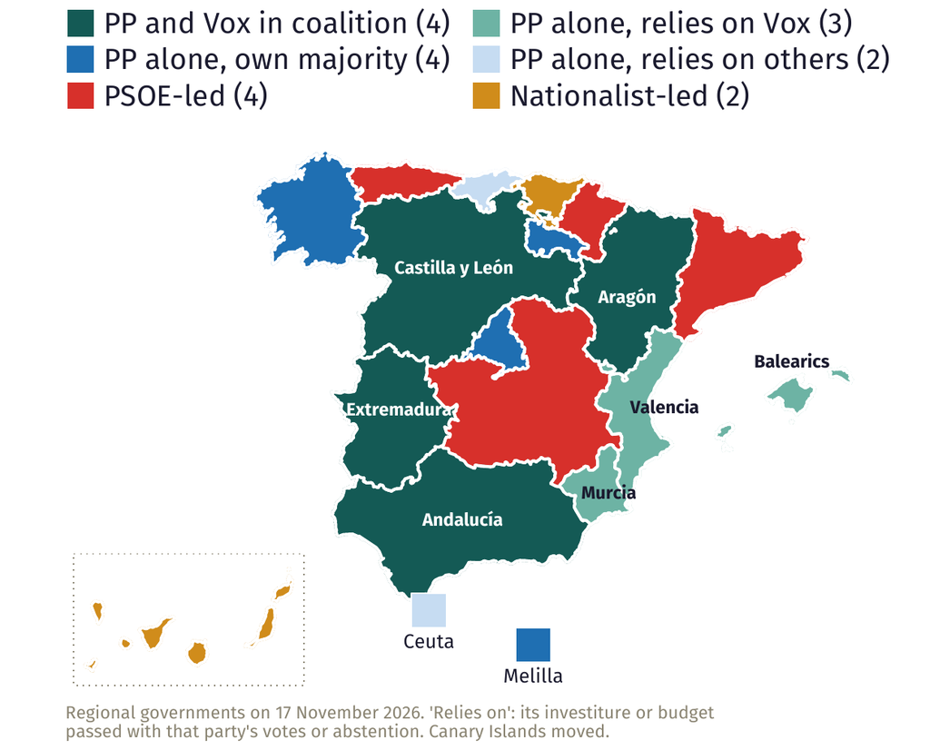

- **Four regions:** Vox sits in the government with the PP, with a vice-president and “national priority” in the pact.
- **Three more:** PP governments that need Vox’s votes.
- These seven regions are home to **44%** of Spain’s voters.

## The far right in European governments

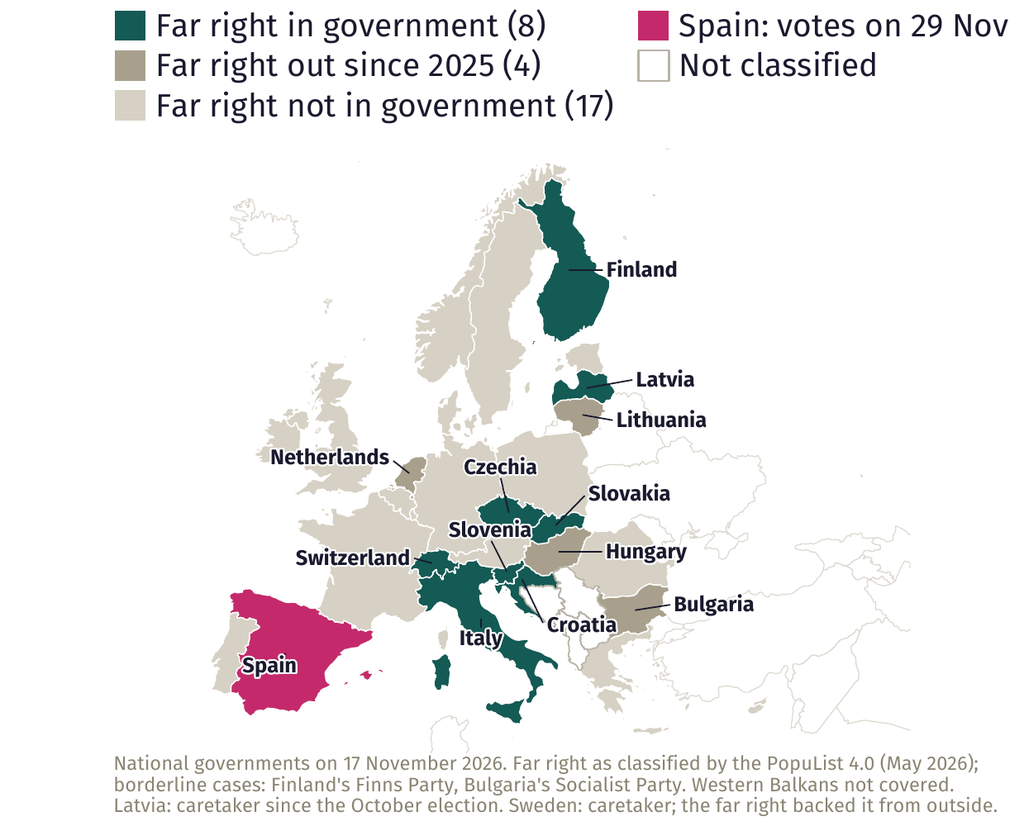

## Spain at a crossroads

What will not change

- A fragmented Congress where governments need partners.
- An electoral system that rewards the big parties and punishes a divided left.
- Two blocs: the left needs the nationalists, the right needs Vox.

What could change

- **Vox in national government** for the first time.
- Laws on the amnesty, immigration, gender, memory and housing.
- With 210 seats, the **courts and the Constitution**.

## Thank you

Alberto López Ortega · a.lopez.ortega@vu.nl · aloport.github.io

## BackupFor the roundtable

## PP lead by polling firm

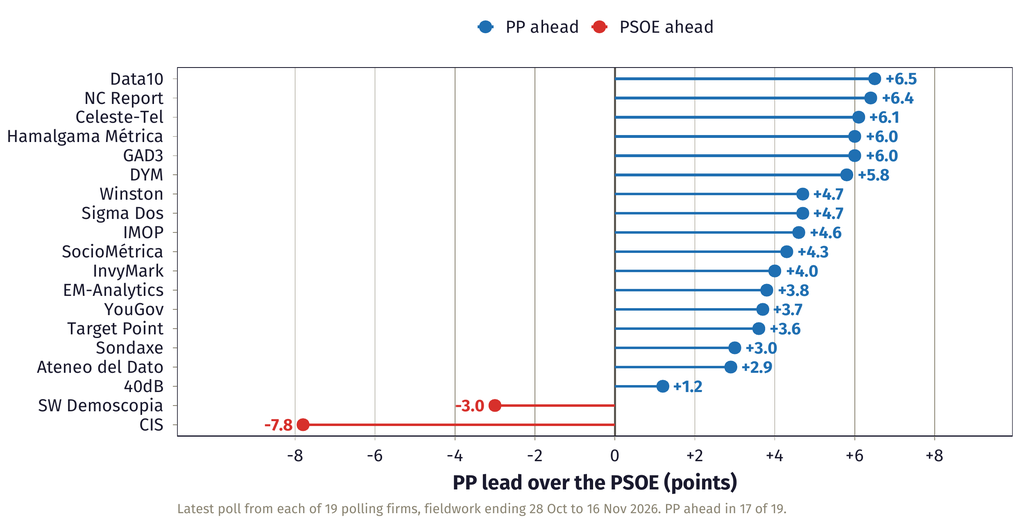

## Model robustness

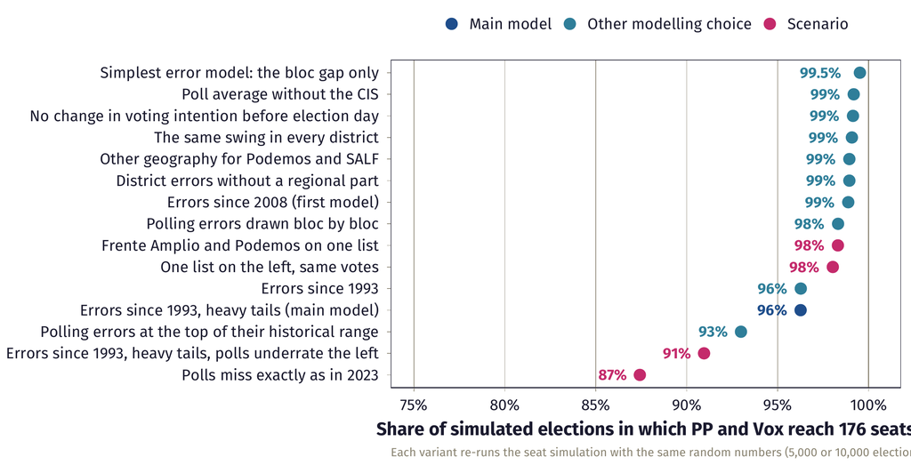

## Polling errors, 2008-2023

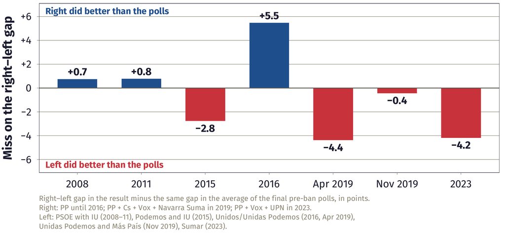

## Majority thresholds

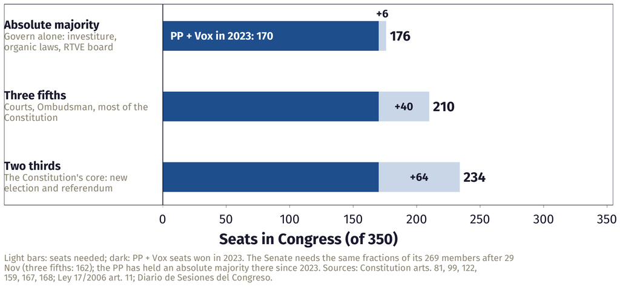

## Vote by age and sex

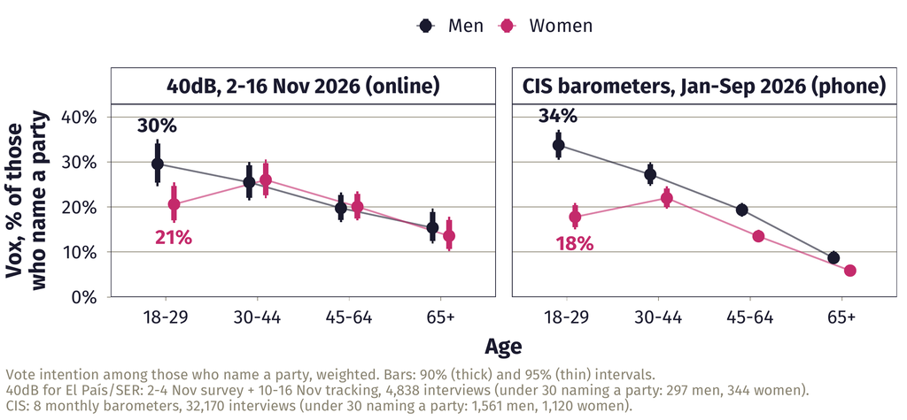

## Preferred prime minister

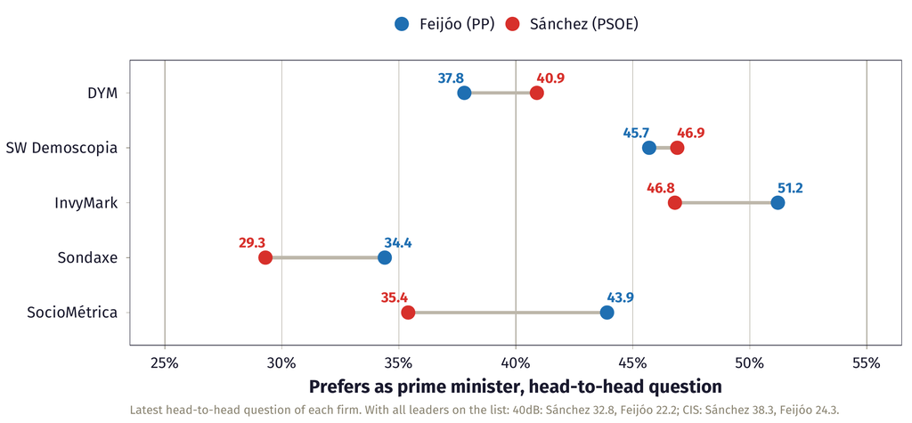

## Closest seats

| District | Seats | Projected last seat | Next in line | Extra votes it needs |
| --- | --- | --- | --- | --- |
| Girona | 6 | PP | ERC | 464 |
| A Coruña | 8 | PSOE | PP | 583 |
| Alicante | 12 | PSOE | PP | 735 |
| La Rioja | 4 | PSOE | Vox | 1,304 |
| Lleida | 4 | PSOE | PP | 1,332 |
| Almería | 6 | PP | PSOE | 1,567 |
| Pontevedra | 7 | PP | PSOE | 5,137 |

## Sources and methods

- **Polls:** latest poll from each of 19 polling firms, fieldwork ending 28 Oct-16 Nov 2026 (each checked against the firm’s or the media outlet’s release); 77 seat projections since the call; 523 polls since 2023 for the bloc series.
- **Seat model:** 10,000 simulated elections from the poll average; polling errors as large as in the 11 general elections since 1993, with heavy tails; 2023 district results moved by proportional swing; D’Hondt with the 3% bar in each district.
- **Vote flows:** 40dB pre-election survey for El País and SER, 2-4 Nov (n = 2,000), and the CIS pre-election survey 3584, 7-30 Oct (n = 45,074), weighted to the 2023 result.
- **Campaign effects:** 40dB daily tracking, 10-17 Nov (3,500 interviews); analysis by Jordi Muñoz (17 Nov, jordi-munoz.github.io/tracking-campanya), replicated and extended.
- **Late deciders:** CIS post-election surveys 3126, 3145, 3248, 3269 and 3420 (microdata). **Young voters:** 40dB (Nov 2026) and CIS barometers (Jan-Sep 2026).
- **Senate:** 2023 results by candidate (BOE-A-2023-18907), 29N Senate lists (BOE-A-2026-23103), my seat model; limited vote per LOREG art. 166.
- **Maps:** regional governments on 17 Nov 2026 (two sources each); far right as classified by The PopuList 4.0.
- **Rules and results:** BOE (Real Decreto 806/2026; proclamation of candidacies, 3 Nov 2026; 2023 results), Constitution arts. 69, 81, 99, 155, 159, 167, 168; LOREG; Kiesraad (Netherlands 2025).
- **Programmes and positions:** PP and Vox programmes for 29N; party statements, Nov 2026.

Alberto López Ortega · a.lopez.ortega@vu.nl · aloport.github.io